# How good do you have to be to win a tennis match?

William Munn

2/15/2022

### Simulating games in a tennis match

What is the relationship between the percentage of points a player will win on their serve, and the percentage of *games* that same player will win? The unique scoring system in tennis means that this relationship is not linear.

```r
result <- play.game("P1",0.6) # ignoring optional arguments that allow a game to begin mid-way
result[[1]]
```

```
## [1] "P1"
```

```r
result[[2]]
```

```
##   point_number server winner
## 1            1     P1     P1
## 2            2     P1     P1
## 3            3     P1     P2
## 4            4     P1     P1
## 5            5     P1     P1
```

Here you can see the results for a player who wins, on average, 60% of their points played on serve. The most important thing is the *on average* part. Since the outcomes of individual points rely on a random number being generated, it's possible (but unlikely) for a player who wins, say, 80% of their service points to still lose a simulated game.

How unlikely, though? If we do a sufficiently large enough number of simulations, we can take a look.

```r
ntimes <- 1000
winners <- sapply(1:ntimes,function(x) {play.game("P1",0.8)[[1]]})
sum(winners=="P1")/length(winners)
```

```
## [1] 0.982
```

The estimate printed below of 98.2% was calculated based on 1000 games being played. Next question: how many times does the simulation need to be run in order for the results to be reliable? The chart below illustrates how quickly the result will converge:

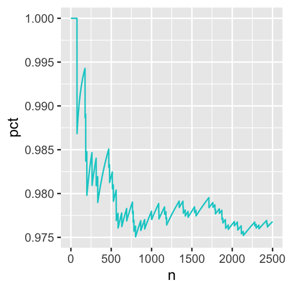

```r
# record how the result changes with respect to number of simulatons
ntimes <- 2500
winners <- sapply(1:ntimes,function(x) {play.game("P1",0.8)[[1]]})
graphdata <- data.table(n = c(1:ntimes),winner = winners)[,pct:=cumsum(winner=="P1")/.I]
p <- ggplot(graphdata, aes(x=n, y=pct)) + geom_line(colour = "cyan 3")
p
```

A few thousand runs seems like enough, then, to give us a reliable answer: a player who wins 80% of points on their serve would expect to win around **98%** of their service games.

At the beginning of this post, I said that the relationship between a player's percentage of points won on serve and their percentage of *games* won on serve was non-linear. We can show this with - you guessed it - more simulations.

```r
# relationship between points won and games won
ntimes <- 1000
srvpct <- rep(seq(0,1,0.025),ntimes)
results <- data.table(srv_pct = srvpct, winner = sapply(srvpct, function(x) {play.game("P1",x)[[1]]}))
results <- results[,.(win_pct = sum(winner == "P1")/.N),by = srv_pct]
p <- ggplot(results, aes(x=srv_pct, y=win_pct)) + geom_line(colour = "cyan 3", size = 0.8)
p
```

[output not shown]

In order words: if you're serving, then the gain you get from increasing your percentage of points won on server is the greatest around 50%. Too much higher than that, the odds of you holding serve are a sure thing, anyway, so the gain becomes less.